Connor Smith  
BMI 550  
Midterm

# Question 1

```
Input: seq = genomic sequence of length N (string)

Output: sub_short = list of shortest subsequences that only occurs once within seq (string)

Assumptions: Sequence is genomic (only contains A,T,C,G)
             All nucelotides are known (no N nucleotides)

BEGIN
    # Get length of sequence
    N = length(seq)
    n = 0 # starting length of subsequences
    sub_found = 'N' # flag for whether or not we have found a sequence yet
    index = 0 # index for use during algorithm
    sub_results = [] # empty list to store occurences

    while n < N and sub_found = 'N'
        n ++ 1
        sub_list = [] # empty list to store potential substrings
        for index in 0:(N-n) # list of all starting indexes for subsequence
            start_index = index
            stop_index = index + n
            sub_list.append(seq[start_index:stop_index]
        # Check for string that only occurs once
        for sub in sub_list
            if num_occurences(string = seq, substring = sub) = 1
                sub_found = 'Y'
                sub_results.append(sub)
    num_seq = length(sub_results)
    Display: num_seq + " sequences found once in sequence with shortest length of " + n
    return sub_short
END
```

# Question 2

a. Chromosome 2  
b. [86815557:86861915]  
c. antisense  
d. 5  
e. 7+6+5+4+6 = 28  
f. 6+5+4+3+5 = 23  
g.  
h.  
i. ANAPC1P1, sense strand, trans (adjacent complementary)

# Question 3

We need genome identifier, Chromosome number, start and end location, and sense/antisense strand.  
For example, the BRCA1 gene would be described as follows:  
Genome: hg38 Chromosome: 17  
Start: 43044295  
End: 43124115  
Strand: Antisense

# Question 4

Resulting alignment:

```
s1 = GWWPD--T
s2 = --WRRKHY
```

(See attached image)

Recursion Formula:
$$ s_{i,j} = max \left\{ \begin{array}{ll} s_{i-1,j-1} + 5 & x=y \\ s_{i-1,j-1} + 1 & x\neq y \, and\, both\, are\, hydrophobic \\ s_{i-1,j-1} -5 & x\neq y \, and\, only\, one\, is\, hydrophobic \\ s_{i-1,j-1} + 0 & x\neq y \, and\, neither\, are\, hydrophobic \\ s_{i-1,j} -2 & if\, opening\, gap\\ s_{i-1,j} -1 & if\, extending\, gap\\ s_{i,j-1} -2 & if\, opening\, gap\\ s_{i,j-1} -1 & if\, extending\, gap\\ \end{array} \right. $$

This type of gap penalty punishes opening new gaps, making it so that we are more likely to continue a gap. This creates some confusion in the recursion algorithm writing, but makes our alignment less segmented. Without this gap penalty, we would also have two potential alignments with the same score (due to the adjacent W's in $s_1$)

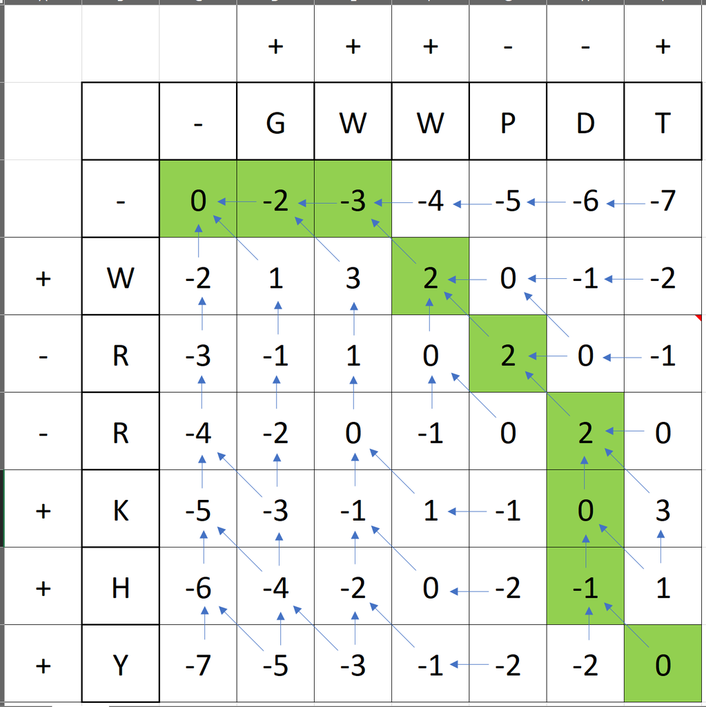

```python
from IPython.display import Image
Image("dp_graph.png")
```

# Question 5

It is important to look at global and local alignment to account for various conditions. Local alignment will find better stretches of matching alignment but operates under the assumption that the rest of the alignment does not matter. Global alignment takes the entire alignment into account, but can match things incorrectly due to how to the gap penalty is set up. A researcher looking for potential mobile elements will want to use local alignment to find the mobile elements and global to verify their results by checking for alternative hypotheses.

# Question 6

```
Inputs: seq1 = first sequence # String,
        seq2 = second sequence # String
Output: result (boolean, TRUE or FALSE) # Whether or not it is a
                                          circular rotation
Assumptions: Matching is exact, no indels and no mismatch
             Nucleotides have not been lost
             both sequences are of equal length

BEGIN
    length_seq = length(seq1)
    # Populate list of all possible rotations of seq2
    rotate_list = []
    for index in range 0:length_seq
        rotate = seq2[i:length_seq]+seq2[0:i] # joins section removed from front to end
        rotate_list.append(rotate)

    # Check if any of the rotated values matches the first string
    match_found = FALSE
    for sub in rotate_list
        if sub = seq1
            match_found = TRUE
        else
            # Do nothing
    return match_found
END
```

# Question 7

```
Inputs: S = suffix tree

Outputs: integer # Number of distinct substrings

Assumptions: Because the suffix tree is compacted, a count of each letter in the tree will give us the number of substrings, as each for each path of the tree each of the letters could be its own substring (including the preceeding ones)

BEGIN
    # Intialize variable
    running_sum = 0
    for path in S
        running_sum += length(path)
    return running_sum
END
```